# Regular Expressions, Data Transformations with SQL, and ggplot2

Sasha Bakker

10/9/2020

```r
library(DBI)
library(RSQLite)
library(dplyr)
```

```r
library(stringr)
library(ggplot2)
library(tidyverse)
```

# Part I - “Scraping”

## Question 1

Set up a database connection to the `SMScorpus.db` file.

```r
# Set up database connection
drv = dbDriver("SQLite")
con = dbConnect(drv, dbname = "SMScorpus.db")
```

## Question 2

List the tables in our database. Which table contains the actual SMS data? Use a SQL query to show the first 10 rows of the table.

- The actual SMS data is contained in the `new_sms_download` table.

```r
# List tables in our database
dbListTables(con)
```

```
## [1] "new_sms_download" "sqlite_sequence"
```

```r
# List fields in our SMS table
dbListFields(con, "new_sms_download")
```

```
##  [1] "sender"         "receiver"       "send_time"      "collect_time"
##  [5] "collect_method" "content"        "native"         "country"
##  [9] "age"            "input_method"   "experience"     "frequency"
## [13] "phone_model"    "collector"      "gender"         "smartphone"
## [17] "lang"           "city"           "id"
```

```r
# Show first 10 rows of table wit SQL query
dbGetQuery(con, "SELECT * FROM new_sms_download LIMIT 10")
```

```
##                              sender                         receiver
## 1  79780a9dbe83fd1e5dd2bd2543e7da2a 0ffc7585148560b7520931d354c00a9b
## 2  79780a9dbe83fd1e5dd2bd2543e7da2a ce3e0c80307aea9b4f656890d19735b3
## 3  79780a9dbe83fd1e5dd2bd2543e7da2a 0ffc7585148560b7520931d354c00a9b
## 4  79780a9dbe83fd1e5dd2bd2543e7da2a 0ffc7585148560b7520931d354c00a9b
## 5  79780a9dbe83fd1e5dd2bd2543e7da2a 0ffc7585148560b7520931d354c00a9b
## 6  79780a9dbe83fd1e5dd2bd2543e7da2a 0ffc7585148560b7520931d354c00a9b
## 7  79780a9dbe83fd1e5dd2bd2543e7da2a 279fab0955409c56520931d354c00a9b
## 8  79780a9dbe83fd1e5dd2bd2543e7da2a 0ffc7585148560b7520931d354c00a9b
## 9  79780a9dbe83fd1e5dd2bd2543e7da2a 0ffc7585148560b7520931d354c00a9b
## 10 79780a9dbe83fd1e5dd2bd2543e7da2a 0ffc7585148560b7520931d354c00a9b
##           send_time collect_time collect_method
## 1  2010.10.24 11:59      2010/11     SMS Export
## 2  2010.10.28 11:53      2010/11     SMS Export
## 3  2010.10.26 22:21      2010/11     SMS Export
```

[output cut: 40 more lines]

# Question 3

Let’s start working on the XML file. Our goal is to extract from it a data frame which is as close as possible to the DB table. First, read the contents of the XML file into a dataframe named `SMScorpus_xml_raw`.

```r
SMScorpus_xml_raw <- readLines("smsCorpus_en_2015.03.09_all.xml", warn = FALSE)
```

Next, create a new dataframe called `SMScorpus_xml` that only contains actual messages.

```r
message_pattern <- "<message id="
# This variable only contains rows of the raw data with "<message id="
SMScorpus <- SMScorpus_xml_raw[grep(x = SMScorpus_xml_raw, pattern = message_pattern)]

# Substitute everything that is not part of a text message
text_exp <- "(.*)<text>|</text>(.*)"
texts <- gsub(text_exp, "", SMScorpus)

# This variable only contains the text message content
SMScorpus_xml <- data.frame(matrix(unlist(texts), nrow = length(texts)))

colnames(SMScorpus_xml) <- c("content")
```

## Question 4

Verify that the number of messages is the same in both your XML version and the DB version. Assign that number as a numeric scalar to a variable called N.

```r
N0 = nrow(SMScorpus_xml)
N = nrow(dbGetQuery(con, "SELECT * FROM new_sms_download"))

N0
```

```
## [1] 55835
```

```r
N
```

```
## [1] 55835
```

- The number of messages is the same for both versions.

## Question 5

**Are the two data sets the same?** In order to answer the question, we will extract the data from the XML file using string manipulations and store it in the same dimensions and variable names as the DB version.

On examining the XML structure, you’ll find that some fields are defined with an equal sign (“=”) and some in a different way.

Write a function called `getXMLfield` which takes the following inputs:

- `field` - the name of the field to extract from each of the XML rows.
- `dat` - the character vector object that contains the XML rows.
- `with_equal_sign` - a logical value that tells the function whether the field is defined with an equal sign or not.
- `type_of_result` - a string whose default value should be “chr”. If it is set to “int”, the function will convert the result to an integer vector.

The output will be a vector that contains the values of the `field` variable.

In addition, the function should convert the XML escaped characters to their actual value.

```r
# The data we want to collect
SMScorpus_db_df <- dbGetQuery(con, "SELECT * FROM new_sms_download")
slice(SMScorpus_db_df, 45719)
```

```
##   sender receiver send_time collect_time collect_method               content
## 1     51  unknown   unknown       2003/4        unknown Bugis oso near wat...
##    native country     age input_method experience frequency phone_model
## 1 unknown      SG unknown      unknown    unknown   unknown     unknown
##   collector  gender smartphone lang    city    id
## 1  howyijue unknown    unknown   en unknown 45719
```

- The cell below is the original function I wrote which takes a desired field as input along with the `dat`, `with_equal_sign`, and `type_of_result` variables.
- I took `field` as the name of the field in which the data frame column will be named rather than the name of the field in the raw data. It was easier for me to keep track of which values will correspond to what in the DB data file. Due to this, the raw “time” field was not vectorized for returning their values.

```r
# SMScorpus only contains rows of the raw data with "<message id="
row1 <- SMScorpus[[1]]

# What the input corresponds to
fields <- c("message id", "text", "srcNumber", "manufactuer", "smartphone", "age", "gender", "nativeSpeaker", "country", "city", "experience", "frequency", "inputMethod", "language", "time", "collector", "time", "destNumber", "method")

# What the user inputs
field_names <- c("id", "content", "sender", "phone_model", "smartphone", "age", "gender", "native", "country", "city", "experience", "frequency", "input_method", "lang", "send_time", "collector", "collect_time", "receiver", "collect_method" )

names(fields) <- field_names


getXMLfield_og <- function(field, dat, with_equal_sign, type_of_result="chr"){

  field_name <- fields[field][[1]]

  if (field_name == "time"){


    if (field == "send_time"){

      exp <- "<messageProfile(.*?)><"

    }

    else if (field == "collect_time"){

      exp <- "<collectionMethod(.*?)><"

    }

    matches <- gregexpr(pattern = exp, tex = dat)
    rmatches <- regmatches(x=dat, m=matches)

  }

  else {

    rmatches <- dat

  }


  if (with_equal_sign == TRUE) {

    exp <- paste("(?<=", field_name, "=\")(.*?)(?=\")", sep="")

  }

  else if (with_equal_sign == FALSE) {

    exp <- paste("(?<=", field_name, ">)(.*?)(?=</", field_name, ")", sep="")

  }

  matches <- gregexpr(pattern = exp, text = rmatches, perl=TRUE)
  result <- regmatches(x=rmatches, m=matches)

  if (field == "content"){

    result <- gsub("&quot;", "\"", result)
    result <- gsub("&apos;", "'", result)
    result <- gsub("&lt;", "<", result)
    result <- gsub("&gt;", ">", result)
    result <- gsub("&amp;", "&", result)

  }


  if (type_of_result == "int") {

    result <- as.integer(result)

  }

  else if (type_of_result == "chr") {

    result <- as.character(result)

  }

  return(result)

}

getXMLfield_og("sender", row1, FALSE)
```

```
## [1] "51"
```

```r
getXMLfield_og("sender", row1, FALSE, "int")
```

```
## [1] 51
```

```r
getXMLfield_og("send_time", row1, TRUE)
```

```
## [1] "unknown"
```

```r
getXMLfield_og("collect_time", row1, TRUE)
```

```
## [1] "2003/4"
```

- I was looking for a way to convert the list produced with “time” input into a matrix so those values could be assigned to the corresponding columns of the XML data frame I am creating.
- Originally, I was using `do.call(rbind, listname)` which worked. However, it wasn’t keeping any null values which made the data frame length of 55796 when it really needs to have N = 55835 rows.
- Eventually, I found the function `rbindlst()` which acts essentially the same but it does keep null values! So, the cell block below shows the package I needed to install in order to use this function.
- The last fix to make this work with the `rbindlst()` function is that I had to transpose the data using `t()`.

```r
#install.packages("data.table")
library(data.table)
```

- The cell below is the function I wrote which takes a desired field as input along with the `dat`, `with_equal_sign`, and `type_of_result` variables.
- This time, the `field` corresponds to the name of the field in the raw data. This will allow for vectorized return of the hierarchical data for “time”.

```r
# SMScorpus only contains rows of the raw data with "<message id="
row1 <- SMScorpus[[1]]

# What the user inputs
fields <- c("message id", "text", "srcNumber", "manufactuer", "smartphone", "age", "gender", "nativeSpeaker", "country", "city", "experience", "frequency", "inputMethod", "language", "time", "collector", "time", "destNumber", "method")

getXMLfield <- function(field, dat, with_equal_sign, type_of_result="chr"){

  field_name <- field
  rmatches <- dat

  if (with_equal_sign == TRUE) {

    exp <- paste("(?<=", field_name, "=\")(.*?)(?=\")", sep="")

  }

  else if (with_equal_sign == FALSE) {

    exp <- paste("(?<=", field_name, ">)(.*?)(?=</", field_name, ")", sep="")

  }

  matches <- gregexpr(pattern = exp, text = rmatches, perl=TRUE)
  result <- regmatches(x=rmatches, m=matches)

  if (field_name == "text"){

    result <- gsub("&quot;", "\"", result)
    result <- gsub("&apos;", "'", result)
    result <- gsub("&lt;", "<", result)
    result <- gsub("&gt;", ">", result)
    result <- gsub("&amp;", "&", result)

  }


  if (type_of_result == "int") {

    result <- as.integer(result)

  }

  else if (typeof(result) == "list"){

    result <- rbindlist(list(result))
    result <- t(result)

  }

  else {

    result <- as.character(result)

  }


  return(result)

}

getXMLfield("srcNumber", row1, FALSE)
```

```
##    [,1]
## V1 "51"
```

```r
getXMLfield("srcNumber", row1, FALSE, "int")
```

```
## [1] 51
```

```r
N == length(complete.cases(SMScorpus_db_df$send_time)) # TRUE
```

```
## [1] TRUE
```

```r
N == length(complete.cases(SMScorpus_db_df$collect_time)) # TRUE
```

```
## [1] TRUE
```

Once you are happy with your function, you should create a new data frame for the XML data.

```r
DBfields <- dbListFields(con, "new_sms_download")
SMScorpus_xml_df <- data.frame(matrix(NA, nrow = N, ncol = length(DBfields)))
colnames(SMScorpus_xml_df) <- DBfields

# Make sure we know all of the field names
sort(DBfields) == sort(field_names)
```

```
##  [1] TRUE TRUE TRUE TRUE TRUE TRUE TRUE TRUE TRUE TRUE TRUE TRUE TRUE TRUE TRUE
## [16] TRUE TRUE TRUE TRUE
```

```r
DBfields
```

```
##  [1] "sender"         "receiver"       "send_time"      "collect_time"
##  [5] "collect_method" "content"        "native"         "country"
##  [9] "age"            "input_method"   "experience"     "frequency"
## [13] "phone_model"    "collector"      "gender"         "smartphone"
## [17] "lang"           "city"           "id"
```

This initializes a data frame that has the same number of rows and the same columns (alongside their names) as the SMS DB file.

We will ignore here two columns from the DB version, send_time and collect_time. So execute:

```r
SMScorpus_xml_df$send_time <- NULL
SMScorpus_xml_df$collect_time <- NULL

# Trying to handle "time" cases automatically
SMScorpus_xml_df[, c("send_time", "collect_time")] <-
  getXMLfield(field = "time", dat = SMScorpus, with_equal_sign = TRUE)
```

You should fill all your columns using the function you created. You need to run it once for each variable. Take care to choose the names correctly!

```r
SMScorpus_xml_df$collect_method <-
  getXMLfield("method", SMScorpus, TRUE)
SMScorpus_xml_df$receiver <-
  getXMLfield("destNumber", SMScorpus, FALSE)
SMScorpus_xml_df$id <-
  getXMLfield("message id", SMScorpus, TRUE, "int")

SMScorpus_xml_df$content <-
  getXMLfield("text", SMScorpus, FALSE)

SMScorpus_xml_df$sender <-
  getXMLfield("srcNumber", SMScorpus, FALSE)
SMScorpus_xml_df$phone_model <-
  getXMLfield("manufactuer", SMScorpus, TRUE)
SMScorpus_xml_df$smartphone <-
  getXMLfield("smartphone", SMScorpus, TRUE)
SMScorpus_xml_df$age <-
  getXMLfield("age", SMScorpus, FALSE)
SMScorpus_xml_df$gender <-
  getXMLfield("gender", SMScorpus, FALSE)
SMScorpus_xml_df$native <-
  getXMLfield("nativeSpeaker", SMScorpus, FALSE)
SMScorpus_xml_df$country <-
  getXMLfield("country", SMScorpus, FALSE)
SMScorpus_xml_df$city <-
  getXMLfield("city", SMScorpus, FALSE)
SMScorpus_xml_df$experience <-
  getXMLfield("experience", SMScorpus, FALSE)
SMScorpus_xml_df$frequency <-
  getXMLfield("frequency", SMScorpus, FALSE)
SMScorpus_xml_df$input_method <-
  getXMLfield("inputMethod", SMScorpus, FALSE)
SMScorpus_xml_df$lang <-
  getXMLfield("language", SMScorpus, TRUE)
SMScorpus_xml_df$collector <-
  getXMLfield("collector", SMScorpus, TRUE)
```

**Print rows 1-10, 20001-20010 and 40001-40010 of your resulting data frame.**

```r
SMScorpus_xml_df[1:10,]
```

```
##    sender receiver collect_method
## 1      51  unknown        unknown
## 2      51  unknown        unknown
## 3      51  unknown        unknown
## 4      51  unknown        unknown
## 5      51  unknown        unknown
## 6      51  unknown        unknown
## 7      51  unknown        unknown
## 8      51  unknown        unknown
## 9      51  unknown        unknown
## 10     51  unknown        unknown
##                                                                                                                                                               content
## 1                                                                                                                                               Bugis oso near wat...
## 2                                                     Go until jurong point, crazy.. Available only in bugis n great world la e buffet... Cine there got amore wat...
## 3                                                                                                                      I dunno until when... Lets go learn pilates...
```

[output cut: 29 more lines]

```r
SMScorpus_xml_df[20001:20010,]
```

```
##                                                 sender
## 20001 c7adea30c5e9bac455066af49acbf76eb63bd4324e6d431c
## 20002 c7adea30c5e9bac455066af49acbf76eb63bd4324e6d431c
## 20003 c7adea30c5e9bac455066af49acbf76eb63bd4324e6d431c
## 20004 c7adea30c5e9bac455066af49acbf76eb63bd4324e6d431c
## 20005 c7adea30c5e9bac455066af49acbf76eb63bd4324e6d431c
## 20006 c7adea30c5e9bac455066af49acbf76eb63bd4324e6d431c
## 20007 c7adea30c5e9bac455066af49acbf76eb63bd4324e6d431c
## 20008 c7adea30c5e9bac455066af49acbf76eb63bd4324e6d431c
## 20009 c7adea30c5e9bac455066af49acbf76eb63bd4324e6d431c
## 20010 c7adea30c5e9bac455066af49acbf76eb63bd4324e6d431c
##                               receiver collect_method
## 20001 6c82416ba4976764d20a707d2be75e0e     SMS Upload
## 20002 6c82416ba4976764d20a707d2be75e0e     SMS Upload
## 20003 6c82416ba4976764d20a707d2be75e0e     SMS Upload
```

[output cut: 51 more lines]

```r
SMScorpus_xml_df[40001:40010,]
```

```
##                                                 sender
## 40001 5947942eb22c76ff040d86eff45702cf8828029e5ca2413a
## 40002 5947942eb22c76ff040d86eff45702cf8828029e5ca2413a
## 40003 5947942eb22c76ff040d86eff45702cf8828029e5ca2413a
## 40004 5947942eb22c76ff040d86eff45702cf8828029e5ca2413a
## 40005 5947942eb22c76ff040d86eff45702cf8828029e5ca2413a
## 40006 5947942eb22c76ff040d86eff45702cf8828029e5ca2413a
## 40007 5947942eb22c76ff040d86eff45702cf8828029e5ca2413a
## 40008 5947942eb22c76ff040d86eff45702cf8828029e5ca2413a
## 40009 5947942eb22c76ff040d86eff45702cf8828029e5ca2413a
## 40010 5947942eb22c76ff040d86eff45702cf8828029e5ca2413a
##                               receiver collect_method
## 40001 c4caecfe70266e7f3aa46133188d52d8     SMS Upload
## 40002 fd0ccca246248842ffb06152f32af4cf     SMS Upload
## 40003 98538082b86a54636a8d70e2f8bf0594     SMS Upload
```

[output cut: 51 more lines]

## Question 6

Let us now check our new data frame that is based on the XML file.

### 6.i.

What is the main glitch in the XML data? Compare your findings to the DB version, using only direct SQL queries. (hint: look for a variable that should have unique entries for each row)

```r
# Print DB data in ascending order
SMSdb <- dbGetQuery(con, "SELECT content FROM new_sms_download ORDER BY content LIMIT 5")
SMSdb
```

```
##                                                                                          content
## 1                                                         \nLol how did u get put in an arm bar.
## 2                                                    _2_|_7_|_6_     _9_|_5_|_1_     _4_|_3_|_8_
## 3     Tere dil ka dard kis ne dekha ha, "Nargis"...,Sab kanjar hain, sirf mammay dekhte hain...!
## 4                                                                                          <#>
## 5                 australia ke elawa aur bhi jagan ab ho raha ha implement..BROADBAND POWER LINE
```

```r
# Print XML data in ascending order
xml_sorted <- SMScorpus_xml_df[order(SMScorpus_xml_df$content),]
row.names(xml_sorted) <- NULL
SMSxml <- xml_sorted['content']
head(SMSxml,5)
```

```
##                                                                                                                                          content
## 1                                                                                                                                              '
## 2                                                                                                                                              '
## 3                                                                                                                                              '
## 4 ''An Amazing Quote'' - "Sometimes in life its difficult to decide whats wrong!! a lie that brings a smile or the truth that brings a tear...."
## 5                                                      ''Life is beautiful only for those who knw how to celebrate the PAIN".-.. :-)Gud nite :-)
```

- The main glitch in the data is with characters that have accents. For example, in the XML data, the character `ü` is written as “Ã¼”. A similar thing occurs for characters that are in a different language. For example, the character `鈥` is written as `éˆ¥`. This glitch also makes it so the data are not comparable in ascending order.

### 6.ii.

Several text messages in the XML data are corrupt. Find those using functions like `table()`, `which()` (or others) and show them. Compare those to the correct messages in the DB version. For full credit, use only SQL queries for the latter. For partial credit you can copy the table into an R data frame and examine it directly with `dplyr` or other commands. Identify the issue that causes the discrepancy.

```r
sum(is.na(SMScorpus_xml_df$content)) # zero
```

```
## [1] 0
```

```r
sum(is.nan(SMScorpus_xml_df$content)) # zero
```

```
## [1] 0
```

```r
sum(SMScorpus_xml_df$content == "") # zero
```

```
## [1] 0
```

```r
sum(SMScorpus_xml_df$content == "NULL") # zero
```

```
## [1] 0
```

```r
sum(is.null(SMScorpus_xml_df$content)) # zero
```

```
## [1] 0
```

```r
anyNA(SMScorpus_xml_df$content) # FALSE
```

```
## [1] FALSE
```

```r
# Are all cases complete?
N == length(complete.cases(SMScorpus_xml_df$content)) # TRUE
```

```
## [1] TRUE
```

```r
tt <- as.data.frame(table(SMScorpus_xml_df$content)) # TRUE
N == sum(tt$Freq)
```

```
## [1] TRUE
```

```r
sum(is.na(SMScorpus_xml_df)) # 663
```

```
## [1] 663
```

```r
sum(is.na(SMScorpus_db_df)) # 0
```

```
## [1] 0
```

```r
colSums(is.na(SMScorpus_xml_df)) # 17 columns contain 39
```

[output not shown]

```r
rows <- SMScorpus_xml_df %>%
  rowid_to_column() %>%
  filter(is.na(sender))
rowids <- rows$rowid
rowids # these are the 39 rows that have the NA values
```

```
##  [1] 14154 14312 14432 15041 15068 15070 15145 15356 15362 15363 15364 15365
## [13] 15386 15442 15524 15525 20876 20894 20895 20896 20897 20898 37509 37519
## [25] 37542 37550 37561 37578 37622 37624 37625 37626 37627 37630 37639 37642
## [37] 37698 50651 51171
```

- It appears I cannot find any empty or NA values in the text messages. All messages are accounted for using the `table()` function. All cases are complete, i.e., have no missing values in the texts.
- There are 663 NA values in the entire table – NOT in the “content” column which holds the texts (it has 0 NA values). This contrasts the DB file which has 0 NA values in the entire table.
- 17 Columns in the XML table each have 39 NA values, which is why the total NA values for the table is 663.

```r
SMScorpus_xml_df[rowids,]
```

```
##       sender receiver collect_method      content native country  age
## 14154   <NA>     <NA>           <NA> character(0)   <NA>    <NA> <NA>
## 14312   <NA>     <NA>           <NA> character(0)   <NA>    <NA> <NA>
## 14432   <NA>     <NA>           <NA> character(0)   <NA>    <NA> <NA>
## 15041   <NA>     <NA>           <NA> character(0)   <NA>    <NA> <NA>
## 15068   <NA>     <NA>           <NA> character(0)   <NA>    <NA> <NA>
## 15070   <NA>     <NA>           <NA> character(0)   <NA>    <NA> <NA>
## 15145   <NA>     <NA>           <NA> character(0)   <NA>    <NA> <NA>
## 15356   <NA>     <NA>           <NA> character(0)   <NA>    <NA> <NA>
## 15362   <NA>     <NA>           <NA> character(0)   <NA>    <NA> <NA>
## 15363   <NA>     <NA>           <NA> character(0)   <NA>    <NA> <NA>
## 15364   <NA>     <NA>           <NA> character(0)   <NA>    <NA> <NA>
## 15365   <NA>     <NA>           <NA> character(0)   <NA>    <NA> <NA>
## 15386   <NA>     <NA>           <NA> character(0)   <NA>    <NA> <NA>
## 15442   <NA>     <NA>           <NA> character(0)   <NA>    <NA> <NA>
```

[output cut: 105 more lines]

```r
SMScorpus[rowids]
```

```
##  [1] "<message id=\"4037\"><text>BEGIN:VCARD"
##  [2] "<message id=\"4195\"><text>BEGIN:VCARD"
##  [3] "<message id=\"4315\"><text>BEGIN:VCARD"
##  [4] "<message id=\"4924\"><text>You are.&#13;"
##  [5] "<message id=\"4951\"><text>dude i woke up and i was in an armbar. i think he overextended it too. &#13;"
##  [6] "<message id=\"4953\"><text>Yo david my arm is all janked up cuz my friend arm barred me so i prob cant workout with you until it stops hurting&#13;"
##  [7] "<message id=\"5028\"><text>O. ..&#13;"
##  [8] "<message id=\"5239\"><text>BEGIN:VCARD"
##  [9] "<message id=\"5245\"><text>BEGIN:VCARD"
## [10] "<message id=\"5246\"><text>BEGIN:VCARD"
## [11] "<message id=\"5247\"><text>BEGIN:VCARD"
## [12] "<message id=\"5248\"><text>BEGIN:VCARD"
## [13] "<message id=\"5269\"><text>BEGIN:VCARD"
## [14] "<message id=\"5325\"><text>BEGIN:VCARD"
## [15] "<message id=\"5407\"><text>BEGIN:VCARD"
```

[output cut: 24 more lines]

# Part II - Exploratory Data Analysis

## Question 1

We will first generate some additional quantitative variables, based on different summaries of the text messages. Here, you may copy the DB table to a local data frame and use `dplyr` to analyze and transform your data. Plots should be generated with `ggplot`.

### 1.i.

Create a new variable that counts the number of characters in a text message.

```r
texts_vec <- unlist(SMScorpus_db_df$content)
char_counts <- nchar(texts_vec)
```

### 1.ii.

Create a new variable that counts the number of words (as in strings that are separated by any type of space) in a text message (you might need to iterate or use an `apply` family function).

```r
word_counts <- sapply(strsplit(texts_vec," "), length)
```

### 1.iii.

Create a new variable that measures the average length of a word in text message (That is, for each text message measure first the number of characters in each word, and average over those).

```r
word_lengths <- sapply(strsplit(texts_vec, " "), nchar)
word_sums <- sapply(word_lengths, sum)

avg_lengths <- word_sums / word_counts # divide the sum of word lengths by N words
```

### 1.iv.

Create a new variable that counts how many exclamation marks appear in a text message. You may use the `str_count` function from the `stringr` package.

```r
exclamations <- str_count(texts_vec, pattern = "!")
```

### 1.v.

Create a new variable that counts how many question marks appear in a text message. You may use the `str_count` function from the `stringr` package.

```r
questions <- str_count(texts_vec, pattern = '\\?')
```

#### 1.vi.

Create a new variable that counts how many ellipsis (“…”) marks appear in a text message. You may use the `str_count` function from the `stringr` package.

```r
dots <- str_count(texts_vec, pattern = '\\.\\.\\.')
```

## Question 2

Analyze our new variables!

- `char_counts` = number of characters in a text message
- `word_counts` = number of words in a text message
- `avg_lengths` = average length of words in a text message
- `exclamations` = number of exclamation marks in a text message
- `questions` = number of question marks in a text message
- `dots` = number of ellipsis in a text message

```r
counts_df <- data.frame(matrix(NA, nrow = length(char_counts), ncol = 6))
colnames(counts_df) <- c('char_counts', 'word_counts', 'avg_lengths', 'exclamations', 'questions', 'dots')

counts_df$char_counts <- char_counts
counts_df$word_counts <- word_counts
counts_df$avg_lengths <- avg_lengths
counts_df$exclamations <- exclamations
counts_df$questions <- questions
counts_df$dots <- dots
```

### 2.A.

Number of characters

#### 2.A.i.

Plot a histogram (normalized to density) of the variable that measures the number of characters in a text message. Select the fill to be red with 0.5 transparency, select the line color to be black. Set the number of bins to 100.

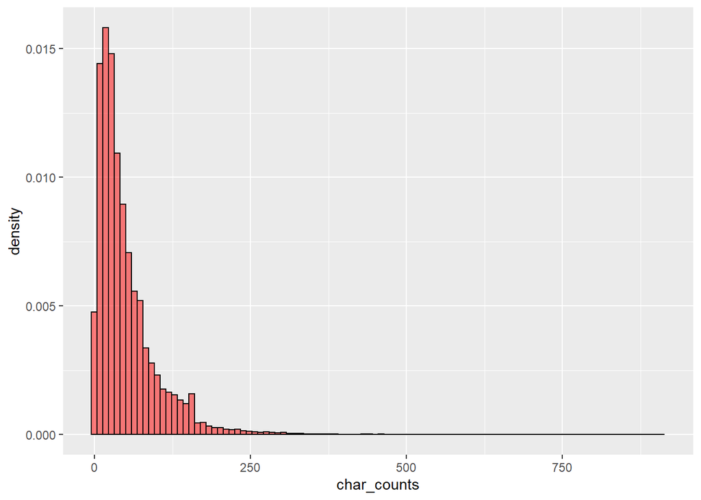

```r
plot1 <- ggplot(counts_df, aes(x=char_counts)) +
  geom_histogram(aes(y=..density..), colour="black", fill="red", alpha=0.5, bins=100)

plot1
```

#### 2.A.ii.

The tail has a weird break a little left of 200. Why do you think it is there? Can you find the exact value based on your qualitative hypothesis (look online to confirm your suspicion)? Add a blue vertical line to the histogram at the cutoff value (try `geom_vline`).

```r
plot_data <- ggplot_build(plot1)
plot_data_df <- plot_data$data[[1]]

xval <- plot_data_df$x[18]
yval <- plot_data_df$density[18]

xval
```

```
## [1] 156.0909
```

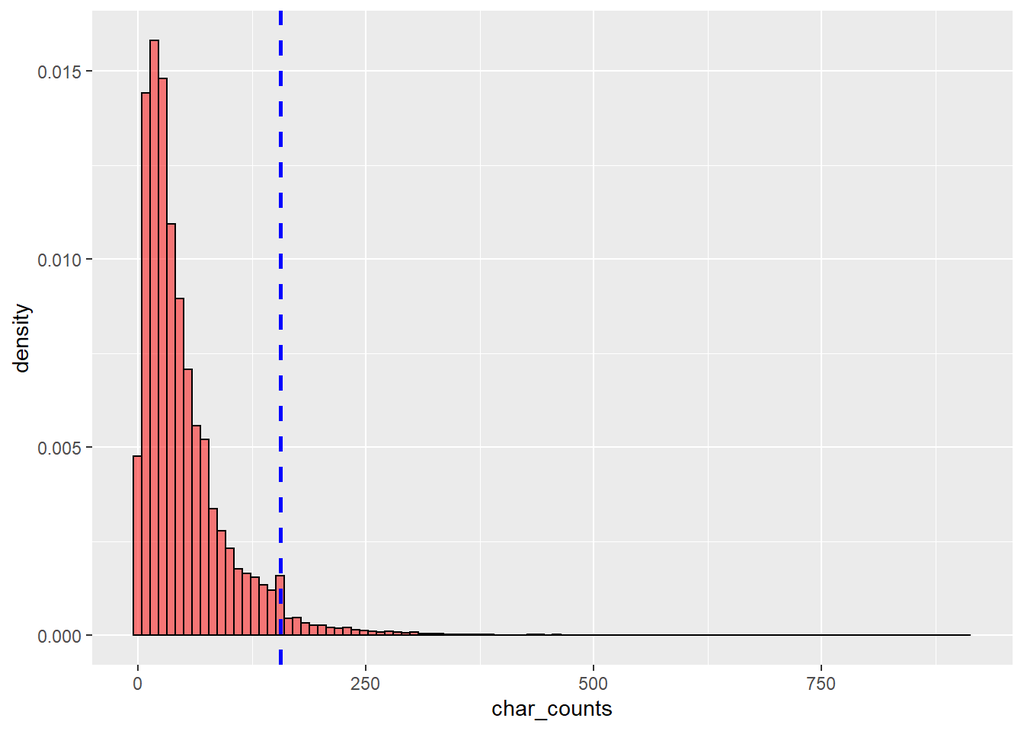

```r
plot1 + geom_vline(aes(xintercept=xval), color="blue", linetype="dashed", size = 1)
```

- The weird break is there at 156 characters because the typical character limit for a single SMS message is 160 characters. There are less texts with the number of characters greater than 160 because less phones are able to support that many characters.

#### 2.A.iii.

Let us see now if there’s a difference between the groups of people that write messages up to the cutoff value you found. First, make a bar plot that shows the proportions of people that write messages below and above this threshold grouped by age. In order for the plot to be more informative, please plot only for age groups which are not “No response” or “unknown” (do not remove these values from the data, just plot without those).

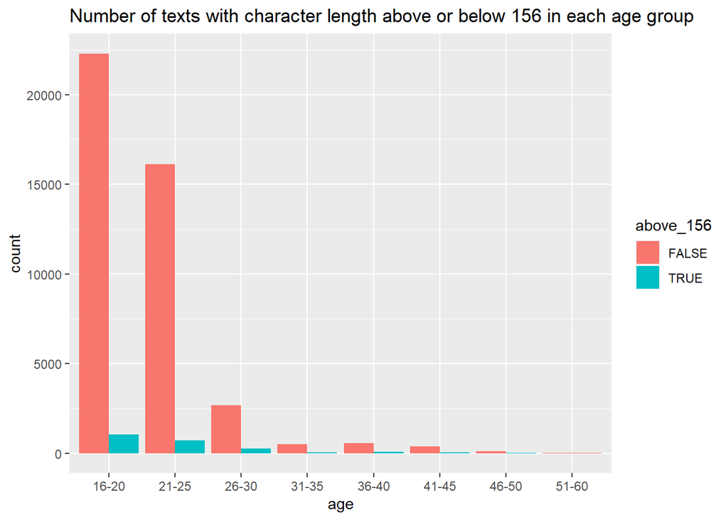

```r
all_df <- cbind(SMScorpus_db_df, counts_df)
threshold <- char_counts > 156
all_df$above_156 = threshold
nn <- length(threshold)

plot2 <- ggplot(data = all_df[which((all_df$age != "unknown") & (all_df$age != "No response")),]) +
  geom_bar(mapping = aes(x = age))

plot_data <- ggplot_build(plot2)
plot_data_df <- plot_data$data[[1]]
nn_vec <- plot_data_df$count # this quantity is the number of texts in each age group
nn_vec <- rep(nn_vec,c(2,2,2,2,2,2,2,1))


ggplot(data = all_df[which((all_df$age != "unknown") & (all_df$age != "No response")),]) +
  geom_bar(mapping = aes(x = age, fill = above_156), position = "dodge") +
  ggtitle("Number of texts with character length above or below 156 in each age group")
```

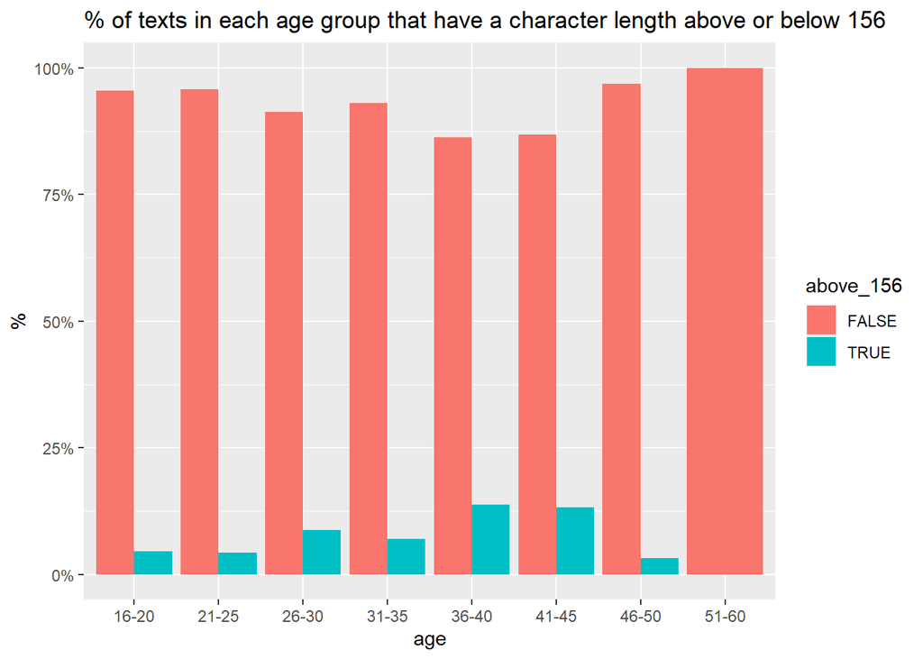

```r
# The percent is given by: (# of texts that are True or False in a particular age group) / (# texts in that particular age group)
ggplot(data = all_df[which((all_df$age != "unknown") & (all_df$age != "No response")),]) +
  geom_bar(mapping = aes(x = age, fill = above_156, y = ..count../nn_vec), position = "dodge") +
  scale_y_continuous(name = "%", labels=scales::percent) +
  ggtitle("% of texts in each age group that have a character length above or below 156")
```

What did you learn from the plot?

- Approximately less than 14% of each age group has texts with the character length above 156.
- The age group 51-60 has no texts with the character length above 156.
- The age group with the greatest percentage of texts with the character length above 156 is the 36-40 age group.

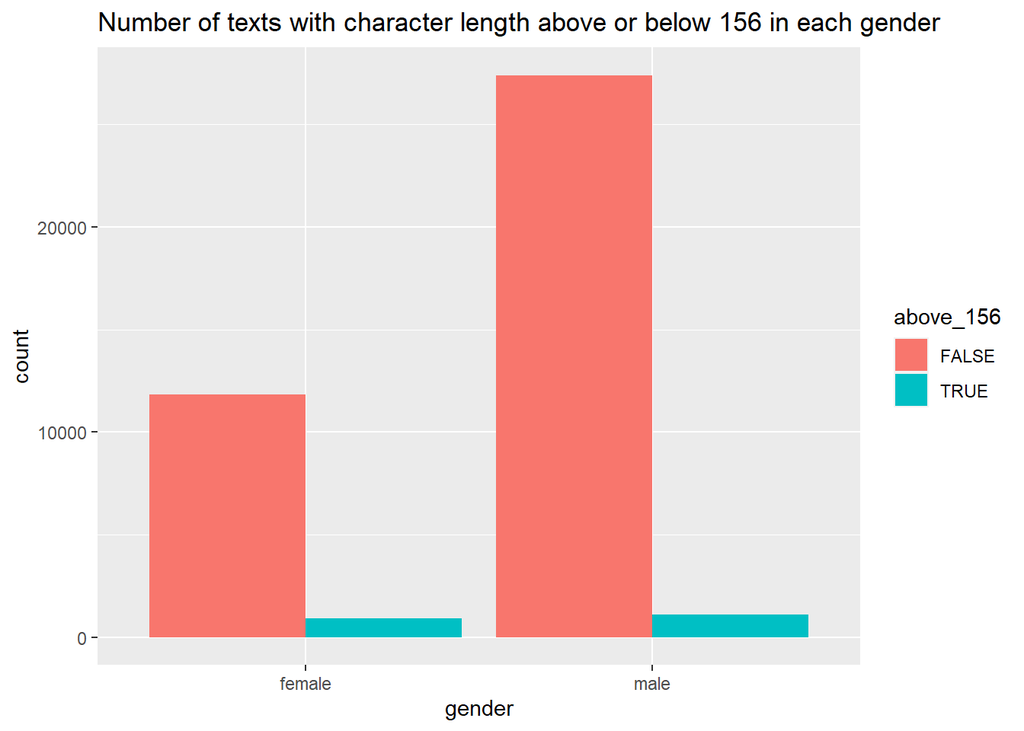

```r
all_df$gender <- gsub("F", "f", all_df$gender)

plot3 <- ggplot(data = all_df[which(all_df$gender != "unknown"),]) +
  geom_bar(mapping = aes(x = gender))

plot_data <- ggplot_build(plot3)
plot_data_df <- plot_data$data[[1]]
nn_vec <- plot_data_df$count # this quantity is the number of texts in each gender
nn_vec <- rep(nn_vec,c(2,2))

ggplot(data = all_df[which(all_df$gender != "unknown"),]) +
  geom_bar(mapping = aes(x = gender, fill = above_156), position = "dodge") +
  ggtitle("Number of texts with character length above or below 156 in each gender")
```

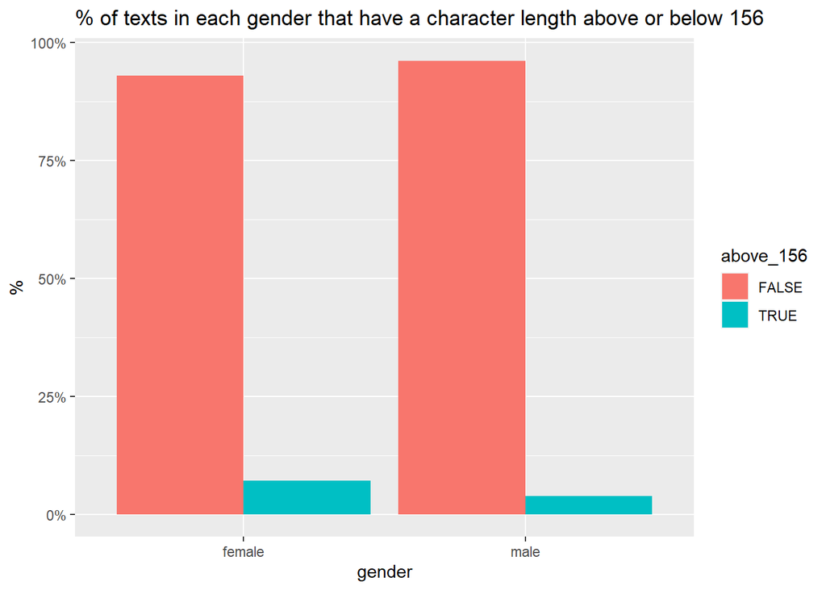

```r
ggplot(data = all_df[which(all_df$gender != "unknown"),]) +
  geom_bar(mapping = aes(x = gender, fill = above_156, y = ..count../nn_vec), position = "dodge") +
  scale_y_continuous(name = "%", labels=scales::percent) +
  ggtitle("% of texts in each gender that have a character length above or below 156")
```

What did you learn from the plot?

- Approximately 7% or less of males and females have texts with the character length above 156.
- Females have almost twice the amount of texts with the the character length above 156 than males

### 2.B.

Number of words

#### 2.B.i.

Make a box plot that best demonstrates how the distributions of the number of words change with age, by gender.

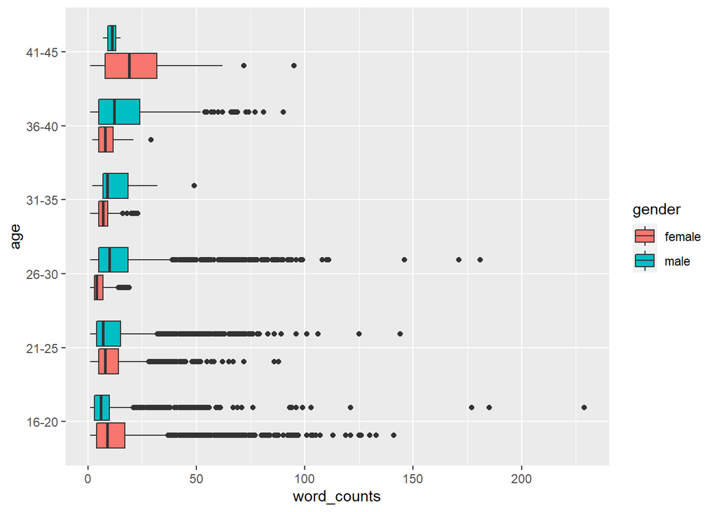

```r
ggplot(data = all_df[which((all_df$age != "unknown") & (all_df$age != "No response") & (all_df$gender != "unknown") & (all_df$age < 46)),], mapping = aes(x = word_counts, y = age, fill=gender)) +
  geom_boxplot()
```

What do you learn from this plot?

#### 2.B.ii.

Make a box plot that best demonstrates whether or not the use of smartphone encourages messages that have more words. Before you do so, change all “Yes” entries in the `smartphone` column to “yes”.

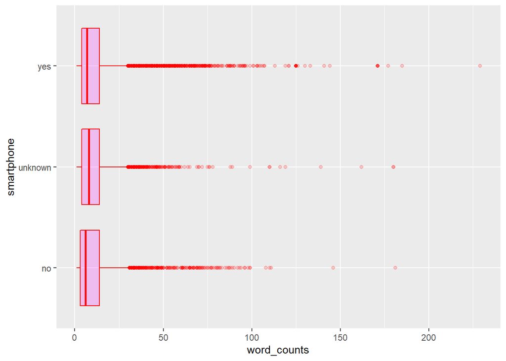

```r
all_df$smartphone <- gsub("Y", "y", all_df$smartphone)

ggplot(data = all_df, mapping = aes(x = word_counts, y = smartphone)) +
  geom_boxplot(color="red", fill="magenta", alpha=0.2)
```

- The use of smartphones does not encourage messages to have more words. This is because the median and the quartile ranges for the ‘yes’ and ‘no’ categories are almost exactly the same. Thus, they have the same distribution. It appears that there are more outliers for the ‘yes’ category, which could be due to more data points in the category. The ‘unknown’ category shows a similar distribution to the ‘yes’ and ‘no’ categories but with a more centered median, rather than having a wider most positive quartile range. Overall, it seems like no matter whether a smartphone is used or not, it is not possible to distinguish these distributions.

### 2.C.

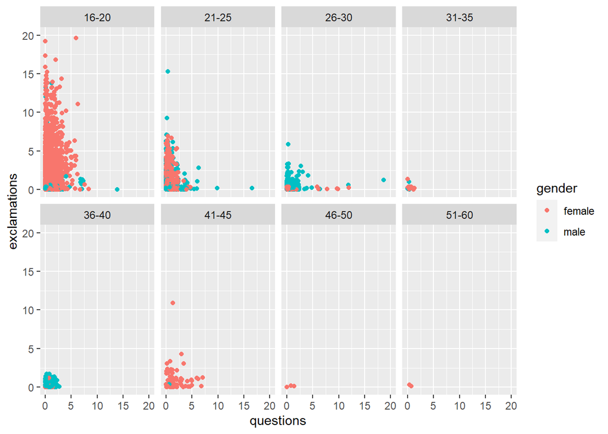

```r
ggplot(data = all_df[which(all_df$gender != "unknown"),]) +
  geom_point(mapping = aes(x = questions, y = exclamations, color = gender), position = "jitter") +
  xlim(0,20) + ylim(0,20) + facet_wrap(~ age, nrow = 2)
```